# Schmidt_Emily_TP6

Emily Schmidt

2024-01-06

## 0.1 Libraries

```r
library(fpp3)
library(ggplot2)
library(tsibble)
library(dplyr)
library(scales)
```

**Exercise 4**. The annual population of Russia is available in the global_economy data set.

## 0.2 Load and Explore Data

**Description**: Economic indicators featured by the World Bank from 1960 to 2017.

```
## [1] "tbl_ts"     "tbl_df"     "tbl"        "data.frame"
```

```
## # A tsibble: 6 x 9 [1Y]
## # Key:       Country [1]
##   Country     Code   Year         GDP Growth   CPI Imports Exports Population
##   <fct>       <fct> <dbl>       <dbl>  <dbl> <dbl>   <dbl>   <dbl>      <dbl>
## 1 Afghanistan AFG    1960  537777811.     NA    NA    7.02    4.13    8996351
## 2 Afghanistan AFG    1961  548888896.     NA    NA    8.10    4.45    9166764
## 3 Afghanistan AFG    1962  546666678.     NA    NA    9.35    4.88    9345868
## 4 Afghanistan AFG    1963  751111191.     NA    NA   16.9     9.17    9533954
## 5 Afghanistan AFG    1964  800000044.     NA    NA   18.1     8.89    9731361
## 6 Afghanistan AFG    1965 1006666638.     NA    NA   21.4    11.3     9938414
```

```
## # A tsibble: 15,150 x 9 [1Y]
## # Key:       Country [263]
##    Country     Code   Year         GDP Growth   CPI Imports Exports Population
##    <fct>       <fct> <dbl>       <dbl>  <dbl> <dbl>   <dbl>   <dbl>      <dbl>
##  1 Afghanistan AFG    1960  537777811.     NA    NA    7.02    4.13    8996351
##  2 Afghanistan AFG    1961  548888896.     NA    NA    8.10    4.45    9166764
##  3 Afghanistan AFG    1962  546666678.     NA    NA    9.35    4.88    9345868
##  4 Afghanistan AFG    1963  751111191.     NA    NA   16.9     9.17    9533954
##  5 Afghanistan AFG    1964  800000044.     NA    NA   18.1     8.89    9731361
##  6 Afghanistan AFG    1965 1006666638.     NA    NA   21.4    11.3     9938414
##  7 Afghanistan AFG    1966 1399999967.     NA    NA   18.6     8.57   10152331
##  8 Afghanistan AFG    1967 1673333418.     NA    NA   14.2     6.77   10372630
##  9 Afghanistan AFG    1968 1373333367.     NA    NA   15.2     8.90   10604346
## 10 Afghanistan AFG    1969 1408888922.     NA    NA   15.0    10.1    10854428
## # ℹ 15,140 more rows
```

```
## [1] 149
```

# 1 Question 1

*Plot the data and comment on its features. What can you observe? To what political , economical or social event/s it can be linked?*

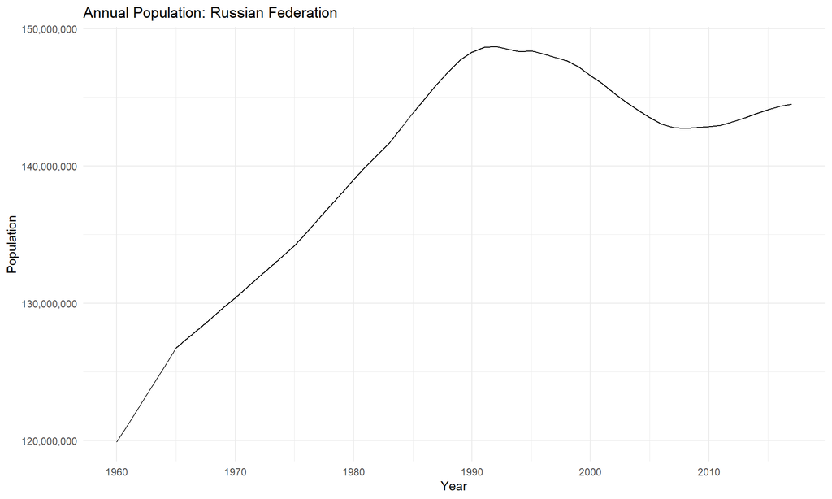

Russia’s annual population had a long period of positive, steady growth from 1960 to the early 1990s. The Russian Federation was facing a significant challenge of elevated mortality rates from non-natural causes, with a majority of such incidents linked to alcoholism [1]. The decline in life expectancy, especially for men in the working-age bracket, had been drastic [1]. In addition, the fertility rate in Russia has dwindled to one of the lowest globally, while simultaneously exhibiting the highest abortion rate [1]. Although this news seems to put a negative effect on the country’s population, the number of birth rates were high, and net positive migration proved to help the upward population trend [2]. There were two migration stages that occurred in the beginning of the 1950s to the mid-1970s [3]. Within this first phase, “Russia lost 2.7 million people to other Soviet republics,” but this turned around in the second stage. Between 1975 and 1991, Russia’s population increased by 2.5 million, which gave those entering the country an opportunity to benefit from state offers [3]. In addition, students played an important role in the population growth since tens of thousands came to study at Russian universities [3]. These are some of the reasons that the trend continued to grow positively throughout those three decades. In 1991, there was a drastic shift, the Soviet Union collapsed. This resulted in a swift change in the trend to be negatively impacted by the economic instability. Daniel Shapiro and Natasha Yefimova-Trilling mentioned how Russia witnessed a steady decline in birth rates coupled with a sharp increase in mortality rates, leading to a relatively smaller cohort of individuals born during this period in comparison to preceding generations. Furthermore, these individuals were currently reaching their optimal childbearing age, resulting in a secondary demographic decline [4]. In the early 1990s, Russia implemented compulsory medical insurance for its citizens, alongside the adoption of fundamental regulatory documents, which would later lead to less deaths [5]. Around 2008, Russia began experiencing a positive trend again in their population growth. This was due to the massive international migration into the country, which by 2017 “was the fourth largest in the world” [4]. Throughout this series, there appears to be no seasonality or cycle.

**Resources**

1. https://www.rand.org/pubs/issue_papers/IP162.html [1]
2. https://www.ifri.org/sites/default/files/atoms/files/ifridemographyvishnevskiengjune2009.pdf [2]
3. https://www.migrationpolicy.org/article/russia-migration-system-soviet-roots [3]
4. https://www.russiamatters.org/blog/russian-population-decline-spotlight-again [4]
5. https://www.mattioli1885journals.com/index.php/MedHistor/article/download/8156/8018/34964 [5]

# 2 Question 2

*Fit a linear trend model and compare this to a piecewise linear trend model with knots at 1993 and 2008.*

According to section 7.1, the regression model allows for a linear relationship between the forecast variable $y$ and a single predictor variable $x$:
$$y_t =
\beta_0 + \beta_1x_1 + \epsilon_t$$
The coefficients $\beta_0$ and $\beta_1$ denote the intercept and the slope of the line respectively. The intercept, $\beta_0$ represents the predicted value of $y$ when $x$ = 0. The slope $\beta_1$ represents the average predicted change in $y$ resulting from a one unit increase in $x$.

## 2.1 Russia’s Linear Trend Model

```
## Series: Population
## Model: TSLM
##
## Residuals:
##      Min       1Q   Median       3Q      Max
## -8715433 -4359379  -617162  4284380  8053401
##
## Coefficients:
##              Estimate Std. Error t value Pr(>|t|)
## (Intercept) 128224895    1313975   97.59  < 2e-16 ***
## trend()        387539      38739   10.00 4.51e-14 ***
## ---
## Signif. codes:  0 '***' 0.001 '**' 0.01 '*' 0.05 '.' 0.1 ' ' 1
##
## Residual standard error: 4939000 on 56 degrees of freedom
## Multiple R-squared: 0.6412,  Adjusted R-squared: 0.6348
## F-statistic: 100.1 on 1 and 56 DF, p-value: 4.5074e-14
```

The estimated regression line for Russia’s population is
$$\hat{y_t} = 128224895 + 387539x_t$$

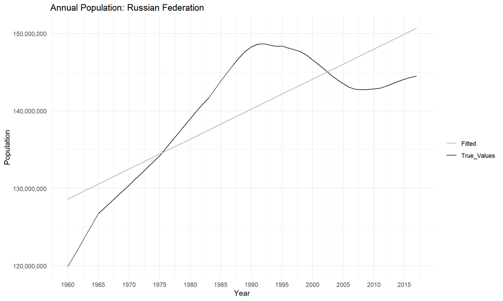

The fitted line has is an upward slope, insinuating a positive relationship between $Population$ and $Year$. The slope coefficient demonstrates that one unit increase in the predictor variable results on average in 387,539 individuals increase in Russia’s population. Both the intercept and the independent variable have very small p-values, indicating that the results are statistically significant. The model has a multiple R-squared of 64.12%, explaining roughly 64% of the variance within the population series which seems to be a reasonably good fit.

There are two main assumptions that need to be fulfilled when using a linear regression model. First, we are assuming that the model is a reasonable approximation to reality. This means that the relationship between the forecast variable and the predictor variables satisfies this linear equation (Section 7.1). The second assumption is in relation to the errors. The residuals should have a mean around zero, they are not autocorrelated, and they are unrelated to the predictor variables. Below shows several plots of the residuals.

```
## Series: Population
## Model: TSLM
##
## Residuals:
##      Min       1Q   Median       3Q      Max
## -8715433 -4359379  -617162  4284380  8053401
##
## Coefficients:
##              Estimate Std. Error t value Pr(>|t|)
## (Intercept) 128224895    1313975   97.59  < 2e-16 ***
## trend()        387539      38739   10.00 4.51e-14 ***
## ---
## Signif. codes:  0 '***' 0.001 '**' 0.01 '*' 0.05 '.' 0.1 ' ' 1
##
## Residual standard error: 4939000 on 56 degrees of freedom
## Multiple R-squared: 0.6412,  Adjusted R-squared: 0.6348
## F-statistic: 100.1 on 1 and 56 DF, p-value: 4.5074e-14
```

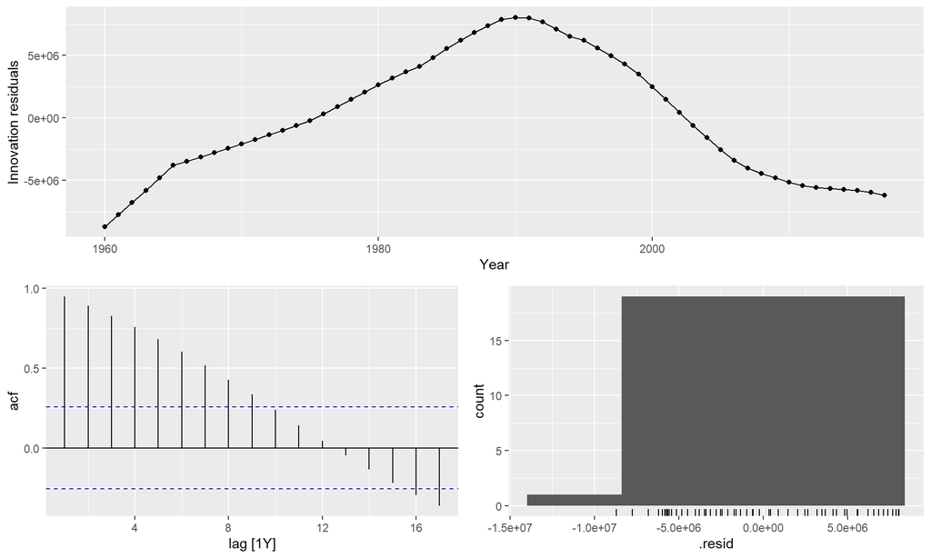

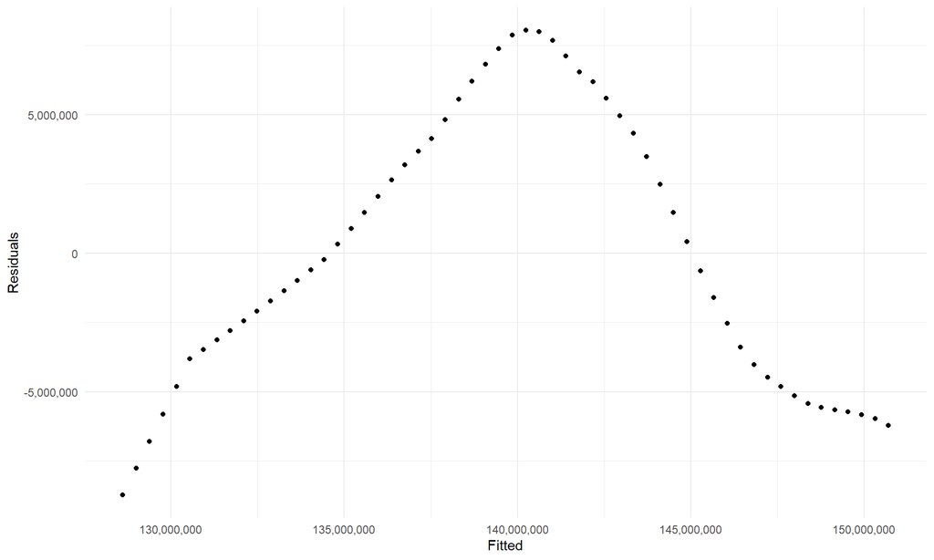

Unfortunately, the residuals look terrible and these assumptions are not met. There is a pattern within the residuals, they do not centered around a mean of 0, and the autocorrelations exceed the blue threshold until Lag 9. Therefore, one may want to transform the here. But, there is another solution!

**Section 7.7: Non-Linear Regression**
There are cases for which simply transforming the data will not be adequate and a more general specification may be required. Then the model we use is
$$y = f(x) +
\epsilon$$
where $f$ is a nonlinear function. In standard (linear) regression, $f(x) = \beta_0 + \beta_1x$. In the specification of nonlinear regression that follows, we allow $f$ to be a more flexible nonlinear function of $x$, compared to simply a logarithmic or other transformation.

One of the simplest specifications is to make $f$ piecewise linear. That is, we introduce points where the slope of $f$ can change. These points are called knots. This can be achieved by letting $x_1 = x$ and introducing variable $x_2$ such that
$$x_2 = (x - c)_+ =\begin{cases} 0 &
if\left(x\right) < c \\
x - c & if\left(x\right) \geq c
\end{cases}$$

The notation $(x - c)_+$ means the value $x - c$ if it is positive and 0 otherwise. This forces the slope to bend at point $c$.

**Resource**: Forecasting: Principles and Practice (3rd ed) [6]

## 2.2 Russia’s Linear Trend Model with Knot at 1993

The knots, $c$, will be placed according to the questions. The first knot is placed at Year 1993.

```
## Series: Population
## Model: TSLM
##
## Residuals:
##      Min       1Q   Median       3Q      Max
## -1327212  -327621   -59849   389742  1043856
##
## Coefficients:
##              Estimate Std. Error t value Pr(>|t|)
## (Intercept) 120328826     195350  615.97   <2e-16 ***
## trend()        895386      10026   89.31   <2e-16 ***
## ---
## Signif. codes:  0 '***' 0.001 '**' 0.01 '*' 0.05 '.' 0.1 ' ' 1
##
## Residual standard error: 548400 on 31 degrees of freedom
## Multiple R-squared: 0.9961,  Adjusted R-squared: 0.996
## F-statistic:  7976 on 1 and 31 DF, p-value: < 2.22e-16
```

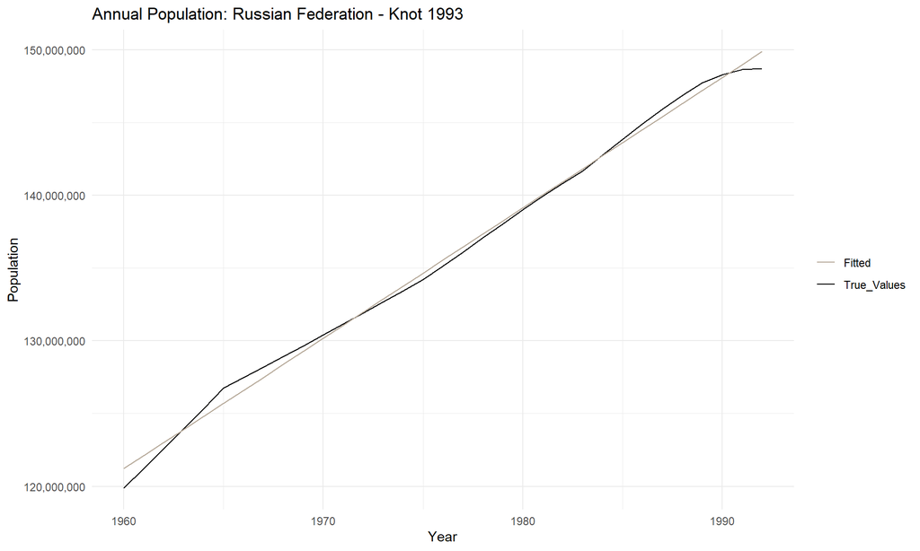

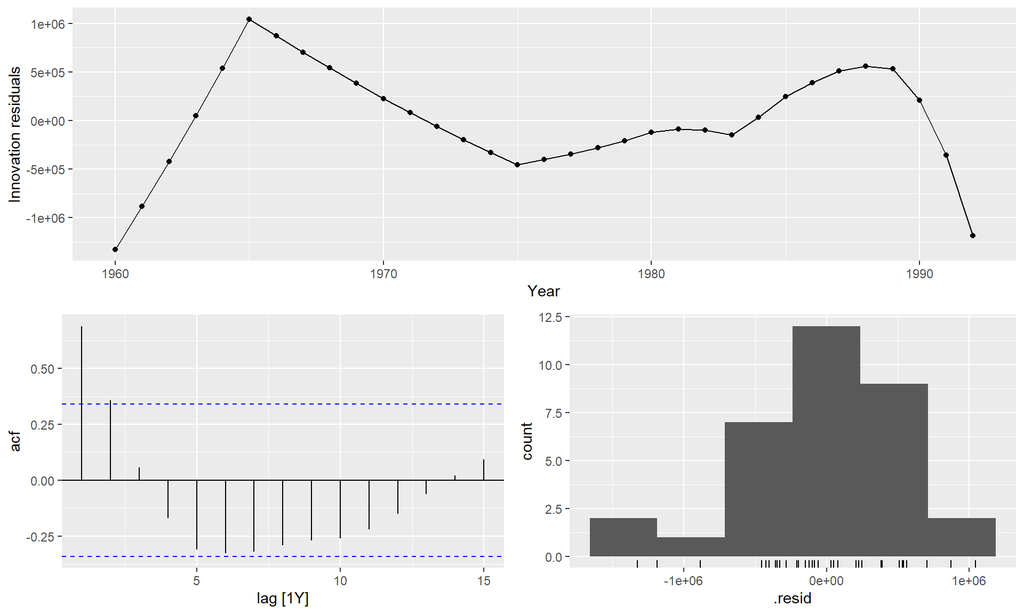

## 2.3 Russia’s Linear Trend Model with Knots at 1993 to 2008

```
## Series: Population
## Model: TSLM
##
## Residuals:
##     Min      1Q  Median      3Q     Max
## -827701 -291612  -56619  344064  612761
##
## Coefficients:
##              Estimate Std. Error t value Pr(>|t|)
## (Intercept) 149805380     241178  621.14  < 2e-16 ***
## trend()       -457678      26526  -17.25 2.43e-10 ***
## ---
## Signif. codes:  0 '***' 0.001 '**' 0.01 '*' 0.05 '.' 0.1 ' ' 1
##
## Residual standard error: 443900 on 13 degrees of freedom
## Multiple R-squared: 0.9582,  Adjusted R-squared: 0.9549
## F-statistic: 297.7 on 1 and 13 DF, p-value: 2.4271e-10
```

There are two places within the time series where the trend changes direction. Hence, there are two identified knots. Prior to 1993, the trend is increasing. Between 1993 to 2008, the trend becomes negative. In 2008, Russia once again begins to have a positive trend in population. Therefore, each of these three elements should be reviewed. For the middle section, it continues to have a higher multiple R-square at 95.82%. The estimated regression line for Russia’s population from 1993 to 2007 is
$$\hat{y_t} = 149805380 +
(-457678)x_t$$

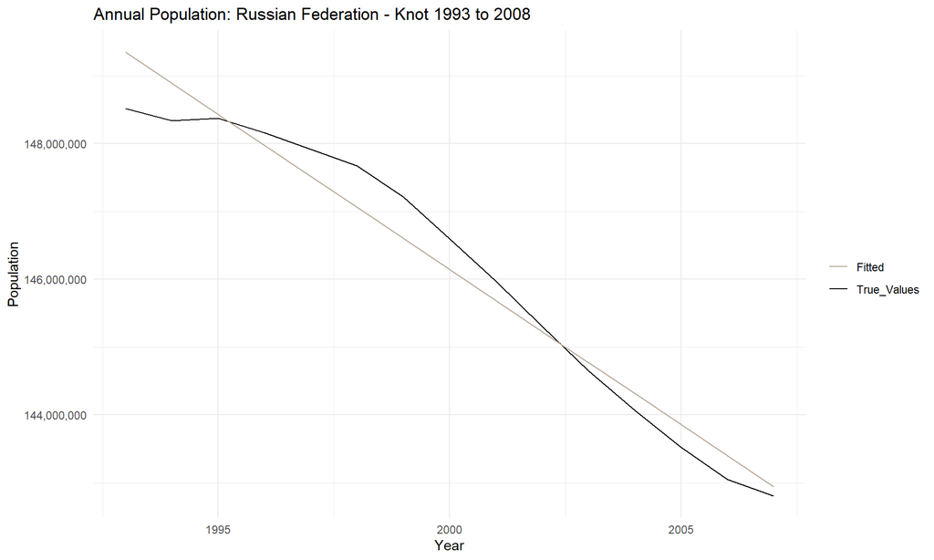

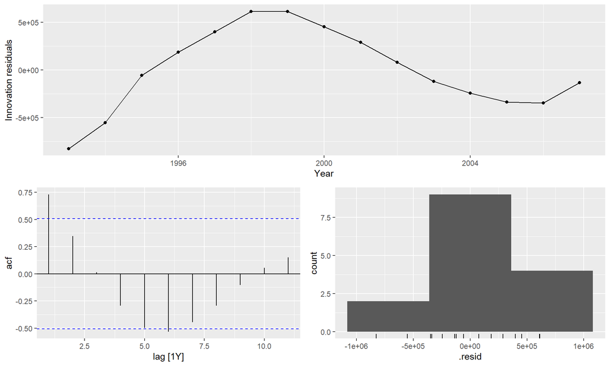

A similar story can be seen for this segment. There is a slight indication that there is correlation within the forecasts since Lag 1 is slightly higher, but we can treat this residual variance as a constant. The histogram may show that the residuals are normal and the mean appears to be close to zero.

## 2.4 Russia’s Linear Trend Model with Knot at 2008

The second knot is placed at Year 2008.

```
## Series: Population
## Model: TSLM
##
## Residuals:
##     Min      1Q  Median      3Q     Max
## -193804  -86627   26528   72007  238448
##
## Coefficients:
##              Estimate Std. Error t value Pr(>|t|)
## (Intercept) 142286979      96549 1473.72  < 2e-16 ***
## trend()        216923      15560   13.94 6.79e-07 ***
## ---
## Signif. codes:  0 '***' 0.001 '**' 0.01 '*' 0.05 '.' 0.1 ' ' 1
##
## Residual standard error: 141300 on 8 degrees of freedom
## Multiple R-squared: 0.9605,  Adjusted R-squared: 0.9555
## F-statistic: 194.3 on 1 and 8 DF, p-value: 6.7893e-07
```

The second knot shows the regression function after 2008 as
$$\hat{y_t} = 142286979 + 216923x_t$$

The multiple R-squared is 96.05% and we can see that the trend is once again positive as it was prior to 1993.

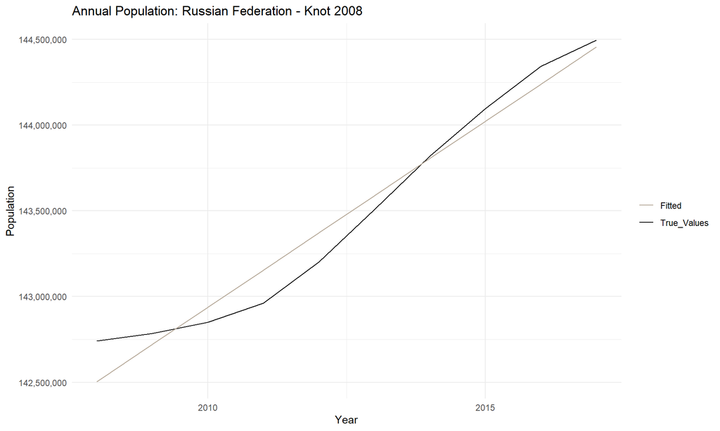

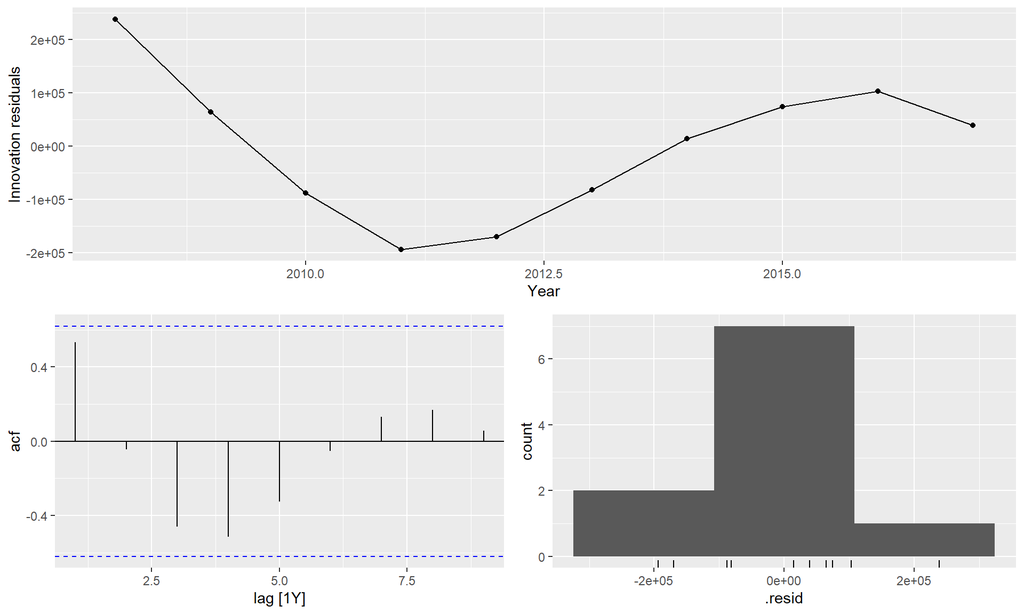

The second knot appears to fulfill all assumptions since the mean is around zero, there are no lags surpassing the threshold, and the distribution appears to be normal.

# 3 Question 3

*Generate forecasts from these two models for the five years after the end of the data, and comment on the results.*

From the overall model, the forecast for the next five years has a very wide prediction interval range to account for the historical observations. There were several knots that were fit to ensure that we are capturing the directional changes in trend. When these are included within the model, the overall fit of the model substantially improves. The 5-year forecast is down below for the overall time series data.

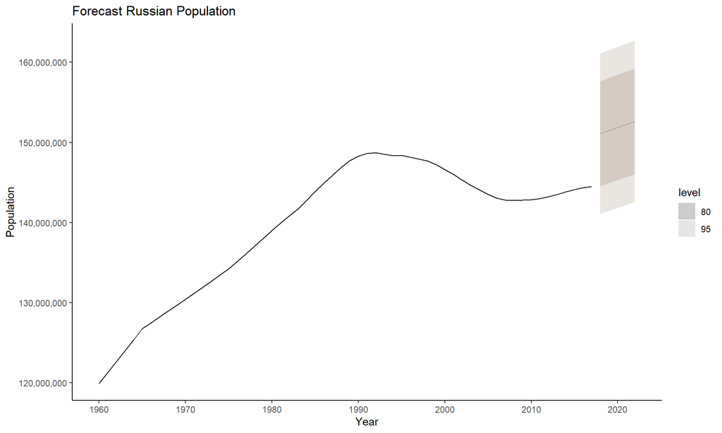

```
## # A fable: 5 x 5 [1Y]
## # Key:     Country, .model [1]
##   Country            .model                      Year          Population  .mean
##   <fct>              <chr>                      <dbl>              <dist>  <dbl>
## 1 Russian Federation TSLM(Population ~ trend())  2018 N(1.5e+08, 2.6e+13) 1.51e8
## 2 Russian Federation TSLM(Population ~ trend())  2019 N(1.5e+08, 2.6e+13) 1.51e8
## 3 Russian Federation TSLM(Population ~ trend())  2020 N(1.5e+08, 2.6e+13) 1.52e8
## 4 Russian Federation TSLM(Population ~ trend())  2021 N(1.5e+08, 2.6e+13) 1.52e8
## 5 Russian Federation TSLM(Population ~ trend())  2022 N(1.5e+08, 2.6e+13) 1.53e8
```

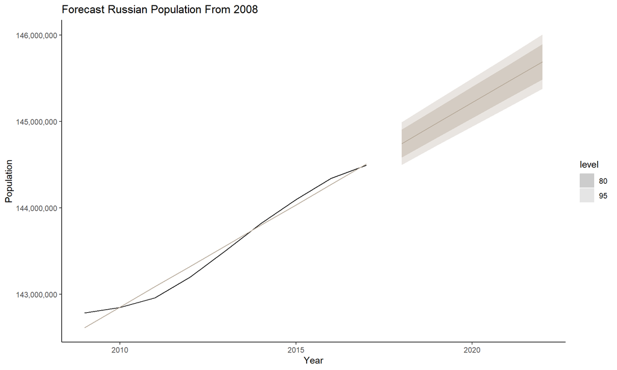

```
## # A fable: 5 x 5 [1Y]
## # Key:     Country, .model [1]
##   Country            .model                      Year          Population  .mean
##   <fct>              <chr>                      <dbl>              <dist>  <dbl>
## 1 Russian Federation TSLM(Population ~ trend())  2018 N(1.4e+08, 1.6e+10) 1.45e8
## 2 Russian Federation TSLM(Population ~ trend())  2019 N(1.4e+08, 1.8e+10) 1.45e8
## 3 Russian Federation TSLM(Population ~ trend())  2020   N(1.5e+08, 2e+10) 1.45e8
## 4 Russian Federation TSLM(Population ~ trend())  2021 N(1.5e+08, 2.3e+10) 1.45e8
## 5 Russian Federation TSLM(Population ~ trend())  2022 N(1.5e+08, 2.6e+10) 1.46e8
```

A similar story can be told about the 2008 knot and the data afterwards. It is expected to have a positive trend into the future. Since data past 2017 is not given, we do not know if this forecast is within the true range of reality. Unfortunately, when looking up real-world data on Russia’s population since 2017, it has been slowly declining [8]. Therefore, this forecast would have not accounted for that change.

**Resource**: https://www.globaldata.com/data-insights/macroeconomic/the-population-of-russia/ [8]

# 4 Question 4

*Repeat analysis for Spain. Adapt knots in question 2 accordingly to the data.*

```
## [1] 1
```

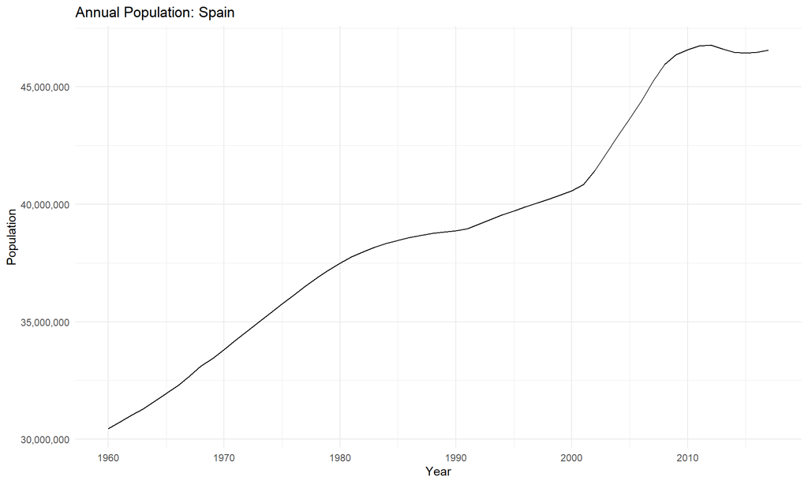

There is a story depicted within this series as there are steeper increases in population to those that are more steady. During the mid-20th century, Spain experienced a substantial surge in population growth, facilitated by the baby boom that followed World War II, along with improvements in medical technology and increased life expectancy, which were also observed in other Western European countries [7]. However, from the 1980s, Spain underwent a demographic transition marked by a steep decline in the country’s fertility rate [7]. This resulted in a relatively modest population growth of two million between the mid-1980s and 2000, compared to the previous pace of two million every five to six years [7]. Notably, the population saw a sharp upswing from 2000 to 2008, buoyed by robust economic growth and a substantial influx of immigrants [7]. However, this growth trajectory was curtailed due to the impact of the Great Recession on the Spanish economy [7]. As of 2020, Spain’s population is estimated to be approximately 46.8 million, which places it as the sixth-largest country in Europe, which can be forecasted later [7]. There appears to be no seasonality or cycle.

**Resource**: https://www.statista.com/statistics/1067088/population-spain-historical [7]

## 4.1 Spain’s Linear Trend Model

```
## Series: Population
## Model: TSLM
##
## Residuals:
##      Min       1Q   Median       3Q      Max
## -1658262  -470754    -6876   689737  1581911
##
## Coefficients:
##             Estimate Std. Error t value Pr(>|t|)
## (Intercept) 30578781     229037  133.51   <2e-16 ***
## trend()       284045       6752   42.06   <2e-16 ***
## ---
## Signif. codes:  0 '***' 0.001 '**' 0.01 '*' 0.05 '.' 0.1 ' ' 1
##
## Residual standard error: 860900 on 56 degrees of freedom
## Multiple R-squared: 0.9693,  Adjusted R-squared: 0.9688
## F-statistic:  1770 on 1 and 56 DF, p-value: < 2.22e-16
```

The estimated regression line for Spain’s population is
$$\hat{y_t} = 30578781 + 284045x_t$$

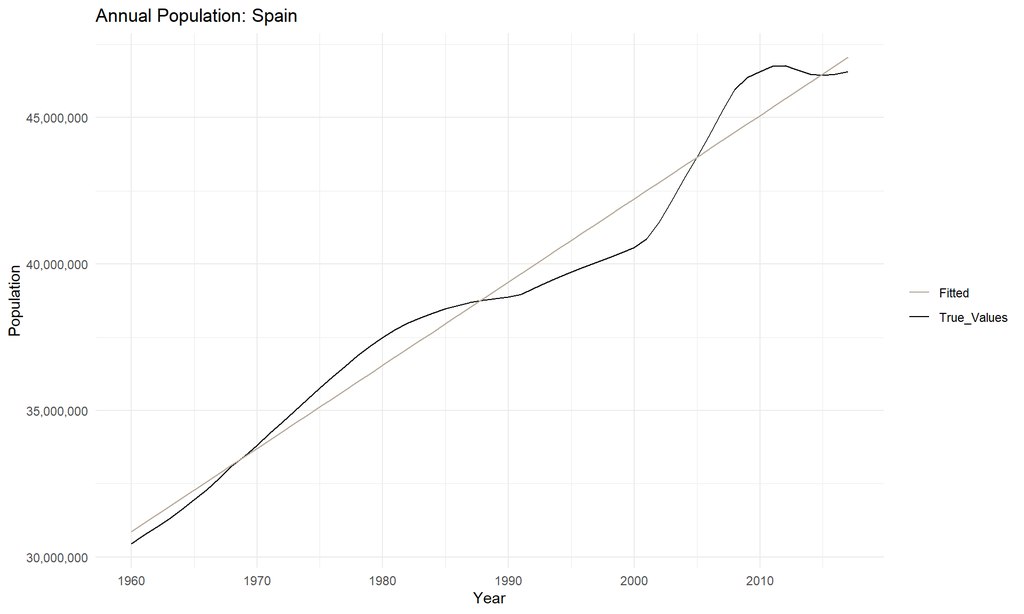

There are two main assumptions that need to be fulfilled when using a linear regression model. First, we are assuming that the model is a reasonable approximation to reality. This means that the relationship between the forecast variable and the predictor variables satisfies this linear equation (Section 7.1). The second assumption is in relation to the errors. The residuals should have a mean around zero, they are not autocorrelated, and they are unrelated to the predictor variables. Below shows several plots of the residuals.

```
## Series: Population
## Model: TSLM
##
## Residuals:
##      Min       1Q   Median       3Q      Max
## -1658262  -470754    -6876   689737  1581911
##
## Coefficients:
##             Estimate Std. Error t value Pr(>|t|)
## (Intercept) 30578781     229037  133.51   <2e-16 ***
## trend()       284045       6752   42.06   <2e-16 ***
## ---
## Signif. codes:  0 '***' 0.001 '**' 0.01 '*' 0.05 '.' 0.1 ' ' 1
##
## Residual standard error: 860900 on 56 degrees of freedom
## Multiple R-squared: 0.9693,  Adjusted R-squared: 0.9688
## F-statistic:  1770 on 1 and 56 DF, p-value: < 2.22e-16
```

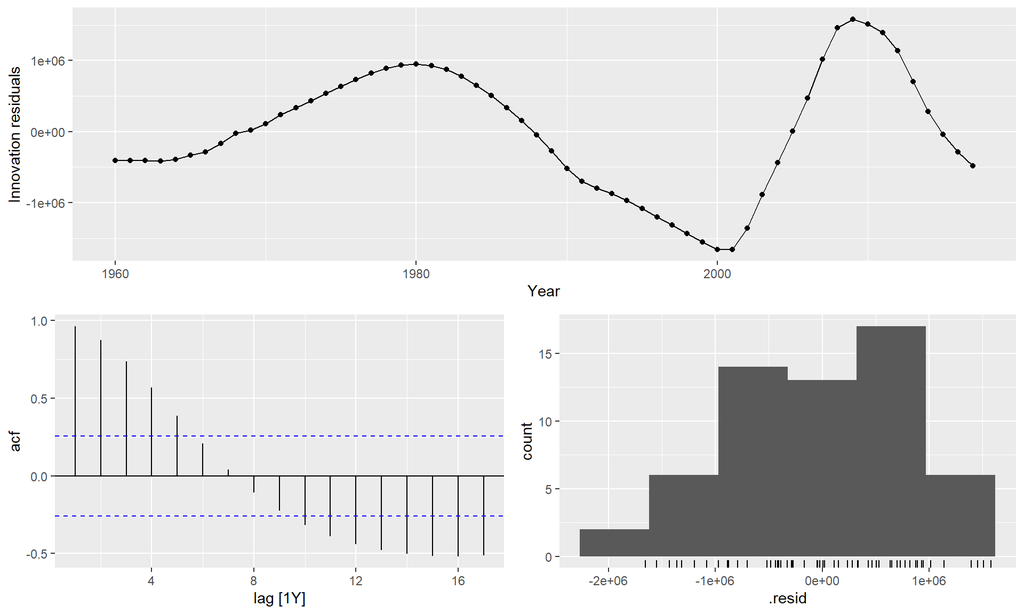

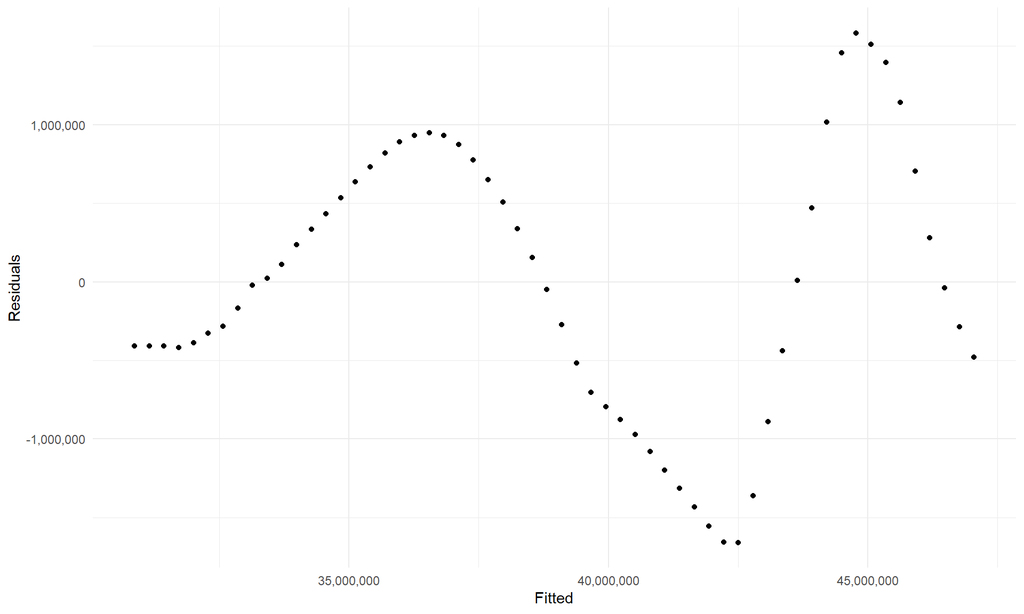

There appear to be three knots that can be easily identified where the slope slightly changes. Since Spain’s population trend is typically always positive, we want to look at the steep parts compared to the more steady growth before a dip at the tail end of the series. Here, we will put knots at 1990, 2002, and 2010. These are approximations of where these knots should go, and there should be an additional analysis to see where the best fit would be with a ‘Spain’ expert.

## 4.2 Spain’s Linear Trend Model with Knot at 1990

```
## Series: Population
## Model: TSLM
##
## Residuals:
##      Min       1Q   Median       3Q      Max
## -1025553  -245868   -18665   344224   521018
##
## Coefficients:
##             Estimate Std. Error t value Pr(>|t|)
## (Intercept) 30304302     148009  204.75   <2e-16 ***
## trend()       318301       8337   38.18   <2e-16 ***
## ---
## Signif. codes:  0 '***' 0.001 '**' 0.01 '*' 0.05 '.' 0.1 ' ' 1
##
## Residual standard error: 395200 on 28 degrees of freedom
## Multiple R-squared: 0.9812,  Adjusted R-squared: 0.9805
## F-statistic:  1458 on 1 and 28 DF, p-value: < 2.22e-16
```

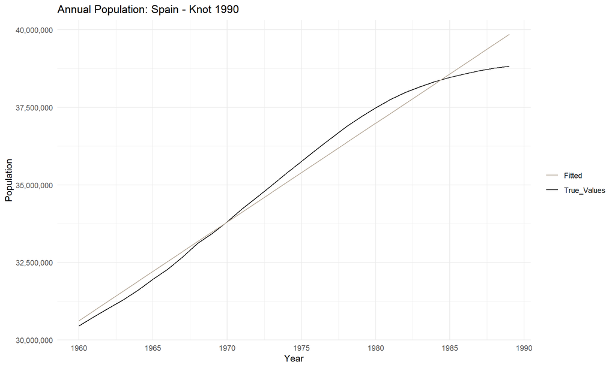

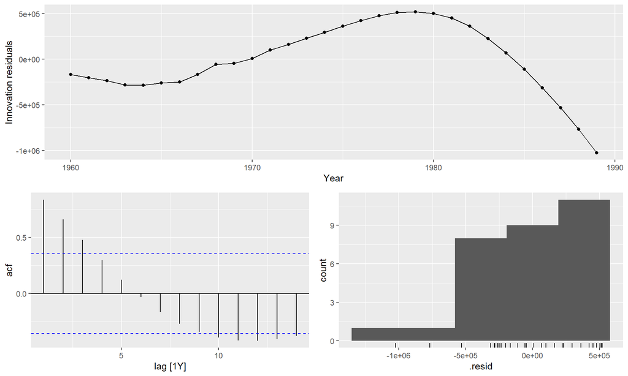

The residuals are not around zero, and they appear to be correlated in some way. Additionally, the histogram continues to be skewed to the left.

## 4.3 Spain’s Linear Trend Model with Knots at 1990 to 2002

```
## Series: Population
## Model: TSLM
##
## Residuals:
##    Min     1Q Median     3Q    Max
## -35356 -23764  -4261  13477  72701
##
## Coefficients:
##             Estimate Std. Error t value Pr(>|t|)
## (Intercept) 38644833      21409  1805.1  < 2e-16 ***
## trend()       177740       2909    61.1 3.35e-14 ***
## ---
## Signif. codes:  0 '***' 0.001 '**' 0.01 '*' 0.05 '.' 0.1 ' ' 1
##
## Residual standard error: 34780 on 10 degrees of freedom
## Multiple R-squared: 0.9973,  Adjusted R-squared: 0.9971
## F-statistic:  3734 on 1 and 10 DF, p-value: 3.3508e-14
```

Once again, we follow the exercise that there are four places within the time series where the trend changes. Hence, there are three identified knots. Each of these three elements should be reviewed. For the first middle section, it continues to have a higher multiple R-square at 99.73%. The estimated regression line for Spain’s population from 1990 to 2001 is
$$\hat{y_t} = 38644833 +
177740x_t$$

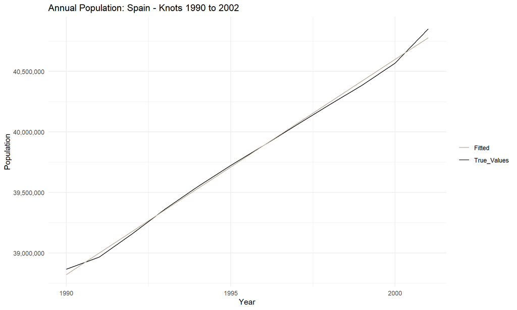

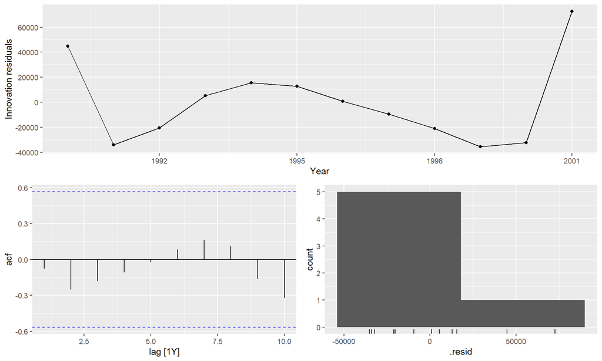

The residuals appear to be distributed around zero, but it is hard to tell if the residuals are normally distributed.

## 4.4 Spain’s Linear Trend Model with Knot from 2002 to 2010

```
## Series: Population
## Model: TSLM
##
## Residuals:
##     Min      1Q  Median      3Q     Max
## -196104  -20924   -3083   43021  121377
##
## Coefficients:
##             Estimate Std. Error t value Pr(>|t|)
## (Intercept) 40748487      84201  483.94 5.25e-15 ***
## trend()       726320      16674   43.56 9.80e-09 ***
## ---
## Signif. codes:  0 '***' 0.001 '**' 0.01 '*' 0.05 '.' 0.1 ' ' 1
##
## Residual standard error: 108100 on 6 degrees of freedom
## Multiple R-squared: 0.9968,  Adjusted R-squared: 0.9963
## F-statistic:  1897 on 1 and 6 DF, p-value: 9.7998e-09
```

The third segment shows the regression function between 2002 and 2010 as
$$\hat{y_t} = 40748487 +
726320x_t$$

The multiple R-square remains high at 99.68%, accounting for about 100% of the variance within the model. This can be seen below as the fitted and true value regression lines mostly lay on top of one another except in 2008 and 2009.

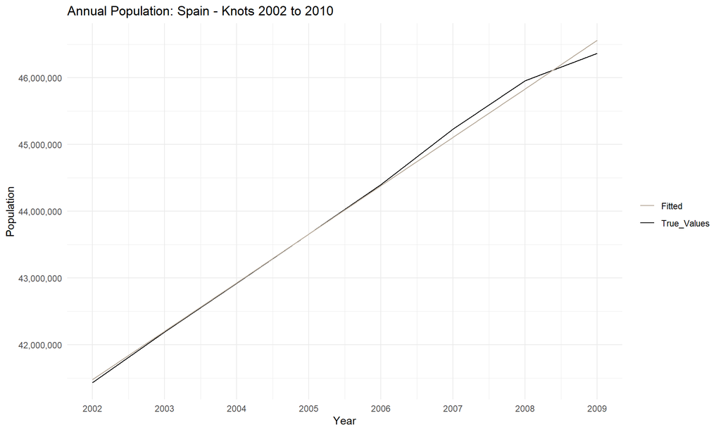

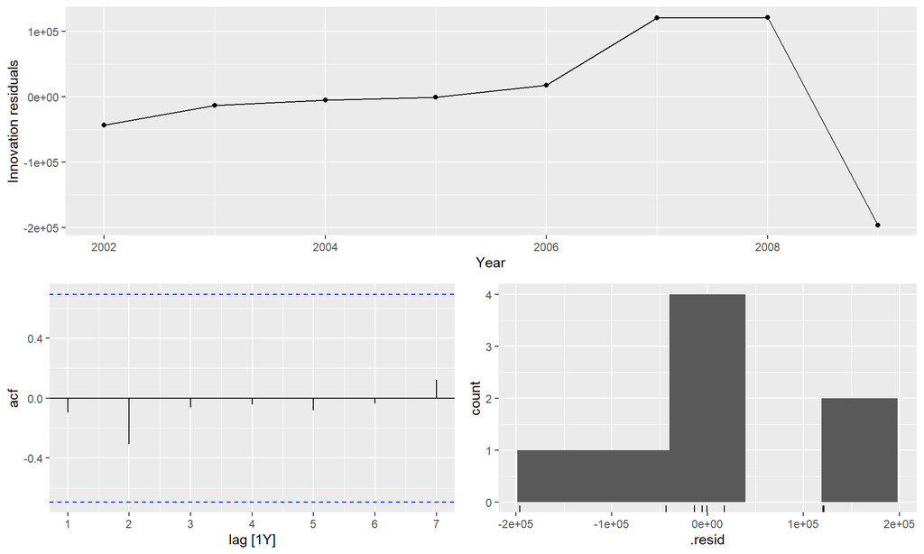

There appears to be no correlation between the lags and the mean is around zero. The histogram could still be considered skewed to the left, but these residuals have been the best performing in terms of meeting the assumptions.

## 4.5 Spain’s Linear Trend Model with Knot at 2010

```
## Series: Population
## Model: TSLM
##
## Residuals:
##
## Coefficients:
##             Estimate Std. Error t value Pr(>|t|)
## (Intercept) 46548226      86328 539.202 1.41e-08 ***
## trend()        -9285      26029  -0.357    0.745
## ---
## Signif. codes:  0 '***' 0.001 '**' 0.01 '*' 0.05 '.' 0.1 ' ' 1
##
## Residual standard error: 82310 on 3 degrees of freedom
## Multiple R-squared: 0.04069, Adjusted R-squared: -0.2791
## F-statistic: 0.1273 on 1 and 3 DF, p-value: 0.74491
```

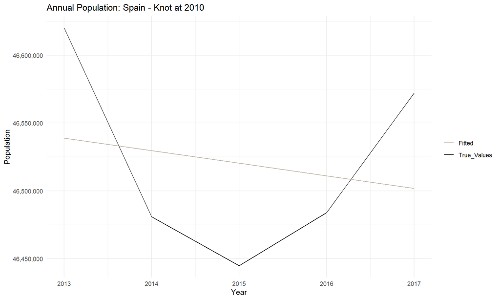

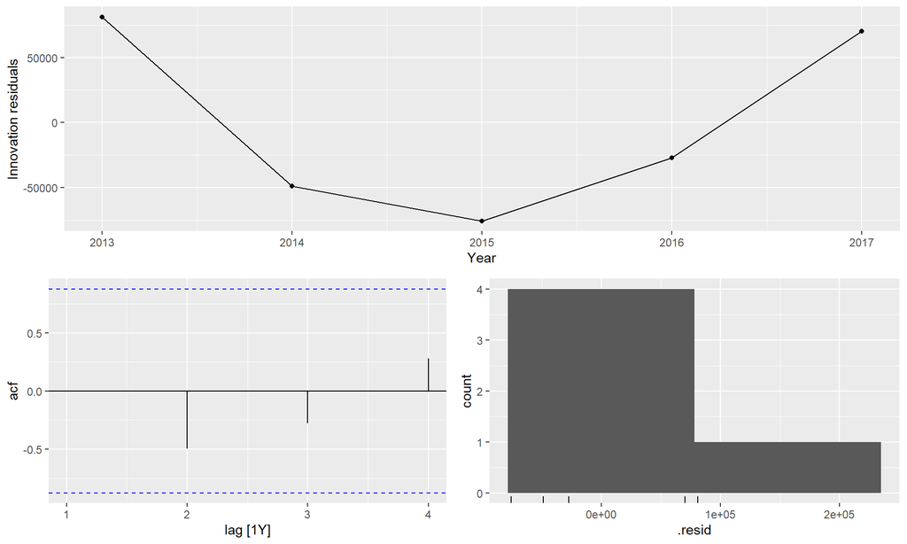

The residuals remain around zero and have no correlation. The histogram shows a skew to the right but this may be due to the low amount of data within this time period.

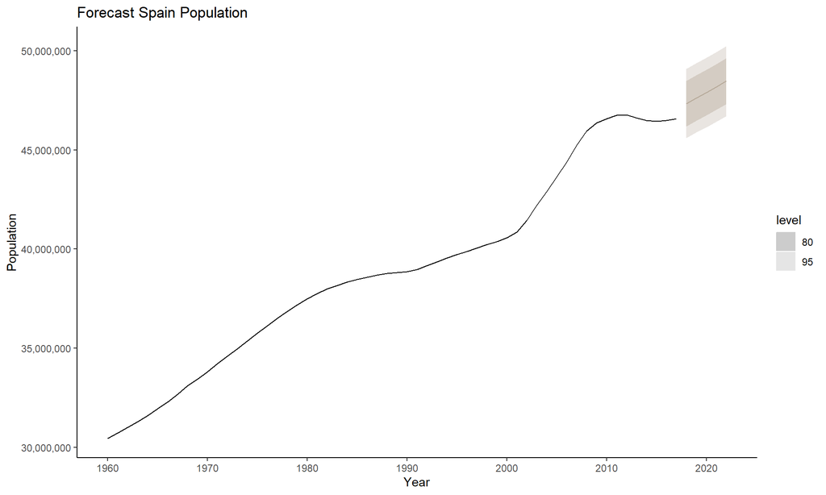

```
## # A fable: 5 x 5 [1Y]
## # Key:     Country, .model [1]
##   Country .model                      Year          Population     .mean
##   <fct>   <chr>                      <dbl>              <dist>     <dbl>
## 1 Spain   TSLM(Population ~ trend())  2018 N(4.7e+07, 7.9e+11) 47337440.
## 2 Spain   TSLM(Population ~ trend())  2019   N(4.8e+07, 8e+11) 47621485.
## 3 Spain   TSLM(Population ~ trend())  2020   N(4.8e+07, 8e+11) 47905531.
## 4 Spain   TSLM(Population ~ trend())  2021   N(4.8e+07, 8e+11) 48189576.
## 5 Spain   TSLM(Population ~ trend())  2022 N(4.8e+07, 8.1e+11) 48473621.
```

Although the trend is decreasing past 2010, the forecast appears to be pointed in a positive direction. This can be attributed to the rest of the historical data having a positive trend as seen by the mean value within the table.

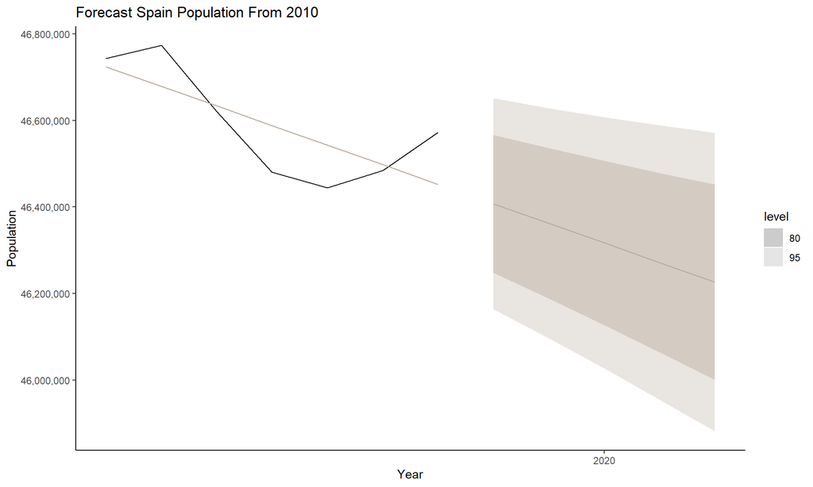

```
## # A fable: 5 x 5 [1Y]
## # Key:     Country, .model [1]
##   Country .model                      Year          Population     .mean
##   <fct>   <chr>                      <dbl>              <dist>     <dbl>
## 1 Spain   TSLM(Population ~ trend())  2018 N(4.6e+07, 1.5e+10) 46407485
## 2 Spain   TSLM(Population ~ trend())  2019 N(4.6e+07, 1.8e+10) 46362299.
## 3 Spain   TSLM(Population ~ trend())  2020 N(4.6e+07, 2.2e+10) 46317113.
## 4 Spain   TSLM(Population ~ trend())  2021 N(4.6e+07, 2.6e+10) 46271927.
## 5 Spain   TSLM(Population ~ trend())  2022 N(4.6e+07, 3.1e+10) 46226741.
```